# Midterm

Author

Zhen Lin

Published

April 27, 2026

```r
library(tidyverse)
library(glue)
library(rio)
library(remotes)
```

### Part A: Data

The following function downloads data from the Oregon Department of education website on the number of students who scored in each performance category on the statewide assessment by race/ethnicity for every school in the state. It takes one argument, year, which must be a two digit integer from 15 to 18 (representing the 2014-15 to 2017-18 school years). It actually won’t work on later years because the file structure changed and I wanted to keep the function simple.

NOTE: This function uses the glue() function from the package of the same name. If you do not already have this package installed, please first install it with install.packages(“glue”). It also uses {rio} for the import, which you should already have installed, but if not, install that first too.

#### 1. (10 points)

Use the function above to download all of the data from the 2014-15 to 2017-18 school years and bind it into a single data frame, using a single function (i.e., one line of code). Note, this may take a minute or two to run, depending on your Internet speed.

```r
download_file <- function(year) {
  link <- glue::glue("https://www.oregon.gov/ode/educator-resources/assessment/TestResults20{year}/pagr_schools_ela_raceethnicity_{year-1}{year}.xlsx")
  rio::import(link, setclass = "tibble", na = c("-", "--", "*"))
}

raw_dat <- map_dfr(15:18, download_file)
head(raw_dat)
```

```
# A tibble: 6 × 21
  `Academic Year` `District ID` District   `School ID` School            Subject
  <chr>                   <dbl> <chr>            <dbl> <chr>             <chr>
1 2014-2015                2063 Adel SD 21         498 Adel Elementary … Englis…
2 2014-2015                2063 Adel SD 21         498 Adel Elementary … Englis…
3 2014-2015                2063 Adel SD 21         498 Adel Elementary … Englis…
4 2014-2015                2063 Adel SD 21         498 Adel Elementary … Englis…
5 2014-2015                2063 Adel SD 21         498 Adel Elementary … Englis…
6 2014-2015                2063 Adel SD 21         498 Adel Elementary … Englis…
# ℹ 15 more variables: `Student Group` <chr>, `Grade Level` <chr>,
#   `Number Proficient (Level 3 or 4)` <chr>,
#   `Percent Proficient (Level 3 or 4)` <chr>, `Number Level 4` <dbl>,
#   `Percent Level 4` <dbl>, `Number Level 3` <dbl>, `Percent Level 3` <dbl>,
#   `Number Level 2` <dbl>, `Percent Level 2` <dbl>, `Number Level 1` <dbl>,
#   `Percent Level 1` <dbl>, `Number of Participants` <dbl>,
#   `Participation Rate` <dbl>, `Number Proficient` <chr>
```

Conduct some basic data cleaning to make your data file look like the following.

Filter for only student groups coded as “White” or “Hispanic/Latino”. Select variables related to the number of students in each of the levels (1 through 4), and not percentages or combined levels. Remove any row that has missing data in any of the n variables

```r
# Filter
clean_data <- raw_dat |>
  filter(`Student Group` %in% c("White","Hispanic/Latino")) |>
# Select variables
  select(
    academic_year = `Academic Year`,
    district = District,
    school = School,
    student_group = `Student Group`,
    grade_level = `Grade Level`,
    `Number Level 1`,
    `Number Level 2`,
    `Number Level 3`,
    `Number Level 4`
  ) |>
    drop_na(starts_with("Number Level")) |>
# Match to the data frame as prompt: using pivot_longer()
    pivot_longer(
      cols = starts_with("Number Level"),
      names_to = "level",
      values_to = "n"
    ) |>
# Change n-> dbl to n->int
    mutate(
      level = str_extract(level, "\\d"),
      n = as.integer(n)
    )

clean_data
```

```
# A tibble: 90,576 × 7
   academic_year district     school       student_group grade_level level     n
   <chr>         <chr>        <chr>        <chr>         <chr>       <chr> <int>
 1 2014-2015     Adrian SD 61 Adrian Elem… Hispanic/Lat… Grade 3     1         2
 2 2014-2015     Adrian SD 61 Adrian Elem… Hispanic/Lat… Grade 3     2         1
 3 2014-2015     Adrian SD 61 Adrian Elem… Hispanic/Lat… Grade 3     3         2
 4 2014-2015     Adrian SD 61 Adrian Elem… Hispanic/Lat… Grade 3     4         1
 5 2014-2015     Adrian SD 61 Adrian Elem… Hispanic/Lat… Grade 6     1         2
 6 2014-2015     Adrian SD 61 Adrian Elem… Hispanic/Lat… Grade 6     2         3
 7 2014-2015     Adrian SD 61 Adrian Elem… Hispanic/Lat… Grade 6     3         2
 8 2014-2015     Adrian SD 61 Adrian Elem… Hispanic/Lat… Grade 6     4         0
 9 2014-2015     Adrian SD 61 Adrian Elem… Hispanic/Lat… Grade 7     1         2
10 2014-2015     Adrian SD 61 Adrian Elem… Hispanic/Lat… Grade 7     2         2
# ℹ 90,566 more rows
```

#### 2. (10 points)

Sum the n across grades and school for each district within each academic year, student group, and level. Calculate the number of schools (unique schools listed) for each district. Also move your data to a wider format where the student groups become new columns, filled by the district n. Remove districts that did not report numbers for one or both student groups (i.e., drop missing data from the new columns). Your data frame should look like the below

```r
# School count by district and year.
school_count <- raw_dat |>
  group_by(
    academic_year = `Academic Year`,
    district = District
  ) |>
  summarize(
    n_schools = n_distinct(School),
   .groups = "drop"
  )

# Hispanic/Latino count by level
his_la_count <- clean_data |>
  filter(student_group == "Hispanic/Latino") |>
  group_by(academic_year, district, level) |>
  summarize(
    hispanic_latino = sum(n),
    .groups = "drop"
  )

# White count by level
white_count <- clean_data |>
  filter(student_group == "White") |>
  group_by(academic_year, district, level) |>
  summarize(
    white = sum(n),
    .groups = "drop"
  )

#Bind everything together
final_data <- his_la_count |>
  left_join(
    white_count,
    by = c("academic_year", "district","level")
  ) |>
  drop_na(hispanic_latino, white) |>
  left_join(
    school_count,
    by = c("academic_year", "district")
  ) |>
  select(
    academic_year,
    district,
    n_schools,
    level,
    hispanic_latino,
    white
  ) |>
  arrange(district, academic_year, level)

final_data
```

```
# A tibble: 1,948 × 6
   academic_year district     n_schools level hispanic_latino white
   <chr>         <chr>            <int> <chr>           <int> <int>
 1 2014-2015     Adrian SD 61         2 1                   6     8
 2 2014-2015     Adrian SD 61         2 2                   6    17
 3 2014-2015     Adrian SD 61         2 3                   6    23
 4 2014-2015     Adrian SD 61         2 4                   1    22
 5 2015-2016     Adrian SD 61         2 1                   5     4
 6 2015-2016     Adrian SD 61         2 2                   3    15
 7 2015-2016     Adrian SD 61         2 3                   5    39
 8 2015-2016     Adrian SD 61         2 4                   0    36
 9 2016-2017     Adrian SD 61         2 1                   2     4
10 2016-2017     Adrian SD 61         2 2                   0    19
# ℹ 1,938 more rows
```

### Part B: Achievement disparities

The estimate_v() function takes 3 arguments in the following order:

1. the data frame including the counts for each group,
2. a character string stating the name of the column with the counts for the reference group, and
3. a character string stating the name of the column with the counts for the focal group. To estimate the average achievement difference between students coded Hispanic/Latino versus White for the first school district in the first year in our data, we would run the following

```r
library(gapr)

final_data[1:4, ] |> # data source - just first four rows for first district
  estimate_v("white", "hispanic_latino") # columns for reference/focal groups
```

```
        auc          v       v_se
1 0.2824054 -0.8141778 0.07283486
```

#### 1. (15 points)

Estimate the average achievement differences in terms of an effect size for every school district in the state that reported data on both student groups (i.e., using the data we created above), for each academic year. Conduct this analysis twice, once using group_by() |> nest() and map() and once using nest_by() |> summarize().

Note, on my computer these took about 1 minute per analysis. It will likely take a bit longer for you, but shouldn’t take too long. You may get a warning. Just go ahead and ignore that for now.

```r
# Method 1: Using group_by() |> nest() and map()
estimate1 <- final_data |>
  group_by(academic_year, district, n_schools) |>
  nest() |>
  mutate(
    estimate = map(
      data,
      ~estimate_v(.x,"white","hispanic_latino")
    )
  ) |>
  unnest(estimate) |>
  rename(v1 = v)

# Method 2: Using nest_by() |> summarize()
estimate2 <- final_data |>
  nest_by(academic_year, district, n_schools) |>
  summarize(estimate = list(
    estimate_v(data,"white","hispanic_latino")
  ),
  .groups = "drop") |>
  unnest(estimate) |>
  rename(v2 = v)

estimate1
```

```
# A tibble: 484 × 7
# Groups:   academic_year, district, n_schools [484]
   academic_year district     n_schools data               auc     v1   v_se
   <chr>         <chr>            <int> <list>           <dbl>  <dbl>  <dbl>
 1 2014-2015     Adrian SD 61         2 <tibble [4 × 3]> 0.282 -0.814 0.0728
 2 2015-2016     Adrian SD 61         2 <tibble [4 × 3]> 0.161 -1.40  0.114
 3 2016-2017     Adrian SD 61         2 <tibble [4 × 3]> 0.422 -0.278 0.381
 4 2017-2018     Adrian SD 61         2 <tibble [4 × 3]> 0.300 -0.742 0.109
 5 2014-2015     Amity SD 4J          4 <tibble [4 × 3]> 0.416 -0.301 0.0204
 6 2015-2016     Amity SD 4J          4 <tibble [4 × 3]> 0.432 -0.243 0.0210
 7 2016-2017     Amity SD 4J          4 <tibble [4 × 3]> 0.337 -0.594 0.0244
 8 2017-2018     Amity SD 4J          4 <tibble [4 × 3]> 0.469 -0.111 0.0207
 9 2016-2017     Annex SD 29          1 <tibble [4 × 3]> 0.588  0.313 0.449
10 2014-2015     Ashland SD 5         6 <tibble [4 × 3]> 0.310 -0.703 0.0168
# ℹ 474 more rows
```

```r
estimate2
```

```
# A tibble: 484 × 6
   academic_year district                        n_schools   auc     v2     v_se
   <chr>         <chr>                               <int> <dbl>  <dbl>    <dbl>
 1 2014-2015     Adrian SD 61                            2 0.282 -0.814 0.0728
 2 2014-2015     Amity SD 4J                             4 0.416 -0.301 0.0204
 3 2014-2015     Ashland SD 5                            6 0.310 -0.703 0.0168
 4 2014-2015     Astoria SD 1                            3 0.383 -0.419 0.00910
 5 2014-2015     Athena-Weston SD 29RJ                   3 0.320 -0.662 0.0686
 6 2014-2015     Baker SD 5J                             9 0.387 -0.408 0.0148
 7 2014-2015     Bandon SD 54                            3 0.574  0.265 0.0383
 8 2014-2015     Banks SD 13                             3 0.416 -0.301 0.0295
 9 2014-2015     Beaverton SD 48J                       53 0.284 -0.806 0.000363
10 2014-2015     Bend-LaPine Administrative SD 1        28 0.319 -0.665 0.00143
# ℹ 474 more rows
```

#### 2. (10 points)

Reproduce the following plot to confirm that the estimates are equivalent across methods.

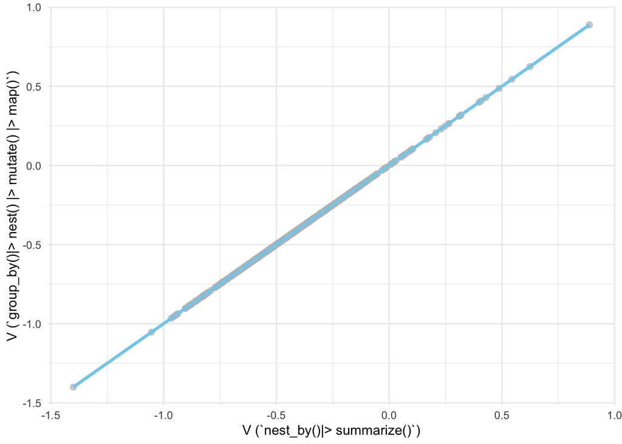

```r
estimate_compare <- estimate1 |>
  left_join(
    estimate2,
    by = c("academic_year", "district", "n_schools")
  )

ggplot(estimate_compare, aes(x = v2, y = v1)) +
  geom_point(color = "gray", size = 2, alpha = 0.7) +
  geom_smooth(method = "lm", se = FALSE, color = "skyblue", linewidth = 1.2) +
  labs(
    x = "V (`nest_by()|> summarize()`)",
    y = "V (`group_by()|> nest() |> mutate() |> map()`)"
  ) +
  theme_minimal()
```

#### 3. (15 points)

The plot below shows the achievement difference estimates for one school district across years. Produce a similar plot to the below for each of the first 100 school districts. Once you’ve created all the plots, reproduce them again using an alternative method. Make sure you don’t miss the caption noting the number of schools in the district.

Hint: You need to select unique districts. You may want to try something like the following:

```r
library(ggtext)

#Method 1
dists <- unique(estimate1$district)[1:100]

estimate1_100 <- estimate1 |>
  filter(district %in% dists)

estimate1_nested <- estimate1_100 |>
  group_by(district, n_schools) |>
  nest()

estimate1_nested
```

```
# A tibble: 127 × 3
# Groups:   district, n_schools [127]
   district              n_schools data
   <chr>                     <int> <list>
 1 Adrian SD 61                  2 <tibble [4 × 5]>
 2 Amity SD 4J                   4 <tibble [4 × 5]>
 3 Annex SD 29                   1 <tibble [1 × 5]>
 4 Ashland SD 5                  6 <tibble [4 × 5]>
 5 Astoria SD 1                  3 <tibble [4 × 5]>
 6 Athena-Weston SD 29RJ         3 <tibble [4 × 5]>
 7 Baker SD 5J                   9 <tibble [4 × 5]>
 8 Bandon SD 54                  3 <tibble [4 × 5]>
 9 Banks SD 13                   3 <tibble [4 × 5]>
10 Beaverton SD 48J             53 <tibble [3 × 5]>
# ℹ 117 more rows
```

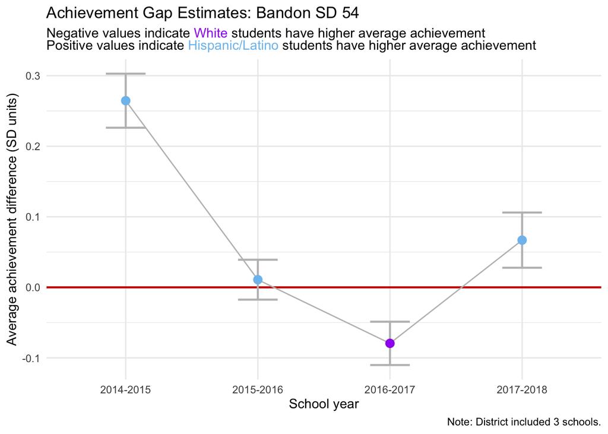

```r
#Method 1
plots_method1 <- estimate1_nested |>
  mutate(
    plot = pmap(
      list(data, district, n_schools),
      ~ ggplot(
        ..1,
        aes(
          x = academic_year,
          y = v1,
          group = 1
        )
      ) +
        geom_hline(
          yintercept = 0,
          color = "red3",
          linewidth = 0.8
        ) +
        geom_line(
          color = "grey",
          linewidth = 0.5
        ) +
        geom_errorbar(
          aes(
            ymin = v1 - v_se,
            ymax = v1 + v_se
          ),
          width = 0.3,
          color = "grey",
          linewidth = 0.8
        ) +
        geom_point(
          aes(color = v1 < 0),
          size = 3
        ) +
        scale_color_manual(
          values = c("FALSE" = "skyblue2", "TRUE" = "purple"),
          guide = "none"
        ) +
        labs(
          title = glue("Achievement Gap Estimates: {..2}"),
          subtitle = "Negative values indicate <span style='color:purple;'>White</span> students have higher average achievement<br>Positive values indicate <span style='color:skyblue2;'>Hispanic/Latino</span> students have higher average achievement",
          x = "School year",
          y = "Average achievement difference (SD units)",
          caption = glue("Note: District included {..3} schools.")
        ) +
        theme_minimal() +
        theme(
          plot.subtitle = ggtext::element_markdown()
        )
    )
  )

plots_method1$plot[[8]]
```

```r
#Method 2

estimate2_100 <- estimate2 |>
  filter(district %in% dists)

estimate2_nested <- estimate2_100 |>
  nest_by(district, n_schools)

estimate2_nested
```

```
# A tibble: 127 × 3
# Rowwise:  district, n_schools
   district              n_schools               data
   <chr>                     <int> <list<tibble[,4]>>
 1 Adrian SD 61                  2            [4 × 4]
 2 Amity SD 4J                   4            [4 × 4]
 3 Annex SD 29                   1            [1 × 4]
 4 Ashland SD 5                  6            [4 × 4]
 5 Astoria SD 1                  3            [4 × 4]
 6 Athena-Weston SD 29RJ         3            [4 × 4]
 7 Baker SD 5J                   9            [4 × 4]
 8 Bandon SD 54                  3            [4 × 4]
 9 Banks SD 13                   3            [4 × 4]
10 Beaverton SD 48J             53            [3 × 4]
# ℹ 117 more rows
```

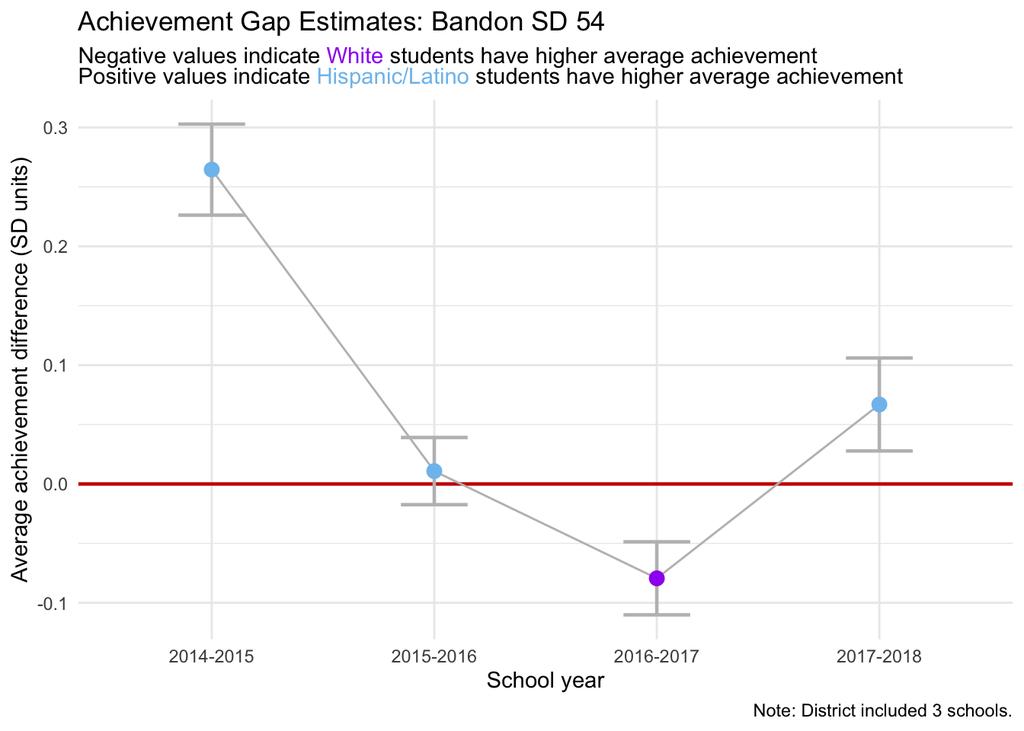

```r
#Method 2
plots_method2 <- estimate2_nested |>
  mutate(
    plot = list(
      ggplot(
        data,
        aes(x = academic_year, y = v2, group = 1)
        ) +
        geom_hline(
          yintercept = 0,
          color = "red3",
          linewidth = 0.8
        ) +
        geom_line(
          color = "grey",
          linewidth = 0.5
        ) +
        geom_errorbar(
          aes(
            ymin = v2 - v_se,
            ymax = v2 + v_se
          ),
          width = 0.3,
          color = "grey",
          linewidth = 0.8
        ) +
        geom_point(
          aes(color = v2 < 0),
          size = 3
        ) +
        scale_color_manual(
          values = c("FALSE" = "skyblue2", "TRUE" = "purple"),
          guide = "none"
        ) +
        labs(
          title = glue("Achievement Gap Estimates: {district}"),
          subtitle = "Negative values indicate <span style='color:purple;'>White</span> students have higher average achievement<br>Positive values indicate <span style='color:skyblue2;'>Hispanic/Latino</span> students have higher average achievement",
          x = "School year",
          y = "Average achievement difference (SD units)",
          caption = glue("Note: District included {n_schools} schools.")
        ) +
        theme_minimal() +
        theme(
          plot.subtitle = ggtext::element_markdown()
        )
    )
  )

plots_method2$plot[[8]]
```

#### 4. (10 points)

Save the plots into a “plots” directory. Make sure the file names are meaningful.

```r
library(here)
library(fs)
library(stringr)

#Method 1
fs::dir_create(here::here("plots", "method1"))

plots_method1_save <- plots_method1 |>
  ungroup() |>
  mutate(
    district_name = district |>
      str_replace_all("[^A-Za-z0-9]+", "_"),
    path = here::here(
      "plots",
      "method1",
      glue("Ave_Ach_diff_2014-2018_{district_name}.png")
    )
  )

#Method 2
fs::dir_create(here::here("plots", "method2"))

plots_method2_filename <-str_replace_all(plots_method2$district,
                                      "[^A-Za-z0-9]+","_")

plots_method2_save <- here::here("plots",
                                 "method2",
                glue("Ave_Ach_diff_2014-2018_{plots_method2_filename}.png"))


#Officially save
# method1
walk2(plots_method1_save$path, plots_method1_save$plot,
      ~ggsave(
        filename = .x,
        plot = .y,
      width = 9.5,
      height = 6.5,
      dpi = 500)
      )

# method 2
plots_method2 |> ungroup() |>
    mutate(path = plots_method2_save) |>
      rowwise()|>
      summarize(
      ggsave(filename = path, plot = plot,
      width = 9.5,
      height = 6.5,
      dpi = 500)
      )
```

```
# A tibble: 127 × 1
   `ggsave(...)`
   <chr>
 1 /Users/zhenlin/Desktop/Desktop - Zhen’s MacBook Air/UO/EDLD 653/EDLD653_Midt…
 2 /Users/zhenlin/Desktop/Desktop - Zhen’s MacBook Air/UO/EDLD 653/EDLD653_Midt…
 3 /Users/zhenlin/Desktop/Desktop - Zhen’s MacBook Air/UO/EDLD 653/EDLD653_Midt…
 4 /Users/zhenlin/Desktop/Desktop - Zhen’s MacBook Air/UO/EDLD 653/EDLD653_Midt…
 5 /Users/zhenlin/Desktop/Desktop - Zhen’s MacBook Air/UO/EDLD 653/EDLD653_Midt…
 6 /Users/zhenlin/Desktop/Desktop - Zhen’s MacBook Air/UO/EDLD 653/EDLD653_Midt…
 7 /Users/zhenlin/Desktop/Desktop - Zhen’s MacBook Air/UO/EDLD 653/EDLD653_Midt…
 8 /Users/zhenlin/Desktop/Desktop - Zhen’s MacBook Air/UO/EDLD 653/EDLD653_Midt…
 9 /Users/zhenlin/Desktop/Desktop - Zhen’s MacBook Air/UO/EDLD 653/EDLD653_Midt…
10 /Users/zhenlin/Desktop/Desktop - Zhen’s MacBook Air/UO/EDLD 653/EDLD653_Midt…
# ℹ 117 more rows
```

#### Extra Credit: (1 point)

From question B.3. above, create a third set of plots that puts together each of the pairs of plots from the two methods to confirm that the plots were produced identically by both methods.

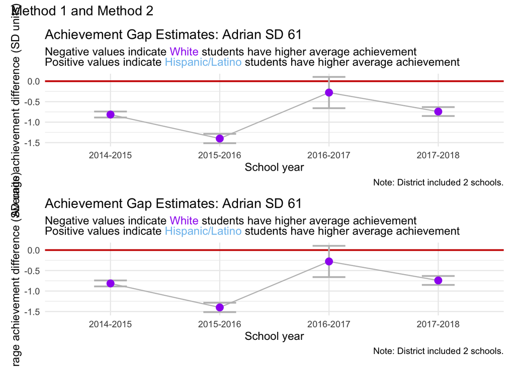

```r
library(patchwork)

paired_plots <- plots_method1 |>
  ungroup() |>
  select(district, n_schools, plot_method1 = plot) |>
  left_join(
    plots_method2 |>
      ungroup() |>
      select(district, n_schools, plot_method2 = plot ),
    by = c("district","n_schools")) |>
  mutate(paired_plot = map2(plot_method1, plot_method2, ~.x / .y +
  plot_annotation(title = "Method 1 and Method 2")
  ))

paired_plots$paired_plot[[1]]
```

```r
#Save the third set of plots
fs::dir_create(here::here("plots", "paired_plots"))
paired_plots_save <- paired_plots |>
  ungroup() |>
  mutate(
    district_name = district |>
      str_replace_all("[^A-Za-z0-9]+", "_"),
    path = here::here(
      "plots",
      "paired_plots",
      glue("Ave_Ach_diff_2014-2018_{district_name}.png")
    )
  )



walk2(
  paired_plots_save$path,
  paired_plots_save$paired_plot,
  ~ ggsave(
    filename = .x,
    plot = .y,
    width = 10,
    height = 16,
    dpi = 500
  )
)
```